# Coursera Capstone Project Week 2: Peer Review

Roel Peters

25 november 2016

## Loading datasets & generating samples

- Removal of redundant whitespaces
- Transformation of all words to full lowercase
- Removal of punctuation

In a later phase of the research, the data is also stripped of its ‘stop words’. Lastly, each dataset also gets a randomly selected sample for processing speed purposes. The samples are 5% of the original datasets.

# Text Features

## Stop words

Before we remove stopwords, let’s have a look at stop word usage for the different datasets. What are the most frequent stop words for each of the datasets? Does the language use of Twitter users differ significantly from bloggers or journalists? We can expect that the Twitter dataset has less stop words since users are confined to 140 characters. But what about bloggers and journalists?

### Stop word density

First we calculate the stop word density for each of the randomly selected subsamples of the three datasets.

```r
twitterStopWordDensity <- round(sum(stopWordsWordCount$Twitter,na.rm=T) / sum(twitterSampleWordCount$Twitter,na.rm=T),4)
newsStopWordDensity <- round(sum(stopWordsWordCount$News,na.rm=T) / sum(newsSampleWordCount$News,na.rm=T),4)
blogStopWordDensity <- round(sum(stopWordsWordCount$Blog,na.rm=T) / sum(blogSampleWordCount$Blog,na.rm=T),4)
```

The stop word density for **Twitter** is **0.274**. For the **news articles** it is **0.2876**. Lastly, for the **blog posts** it is **0.3346**. Not surprisingly, the stop word density for Twitter is lower than for the news articles and blog posts. Also, the stop word density is higher for blog posts than for news articles. A possible hypothesis is that news articles are written by professional journalists and they write in a more clear and readable language that uses fewer stop words.

### Popular stop words

The next step is to identify the most popular stop words for each of the datasets.

This is the top 10 for stop word usage for the subsample of collected tweets. Since Twitter allows for direct communication between people, the word ‘you’ is more prevalent than in the other datasets.

```r
    print(head(stopWordsWordCountShare[order(-stopWordsWordCountShare$Twitter),c(1,2)],10),row.names=F)
```

```
##  word Twitter
##   the  0.0408
##   you  0.0237
##   and  0.0189
##   for  0.0167
##  that  0.0102
##  with  0.0077
##  your  0.0074
##  have  0.0073
##  this  0.0071
##   are  0.0069
```

```r
    print(head(stopWordsWordCountShare[order(-stopWordsWordCountShare$Blog),c(1,3)],10),row.names=F)
```

```
##  word   News
##   the 0.0695
##   and 0.0320
##  that 0.0126
##   for 0.0126
##   you 0.0033
##   was 0.0079
##  with 0.0093
##  this 0.0043
##  have 0.0052
##   but 0.0053
```

```r
    print(head(stopWordsWordCountShare[order(-stopWordsWordCountShare$News),c(1,4)],10),row.names=F)
```

```
##  word   Blog
##   the 0.0636
##   and 0.0371
##   for 0.0125
##  that 0.0159
##  with 0.0097
##   was 0.0097
##   his 0.0038
##  from 0.0050
##   but 0.0069
##  have 0.0074
```

## n-grams

### Top 10 Twitter 1-gram

```r
print(head(twitter1GCount,10),row.names=F)
```

```
##    word count
##    just  7410
##    like  6003
##     get  5465
##    love  5243
##    good  4903
##    will  4814
##  thanks  4480
##     day  4476
##     can  4434
##    dont  4423
```

### Top 10 Twitter 2-gram

```r
print(head(twitter2GCount,10),row.names=F)
```

```
##             word count
##        right now   795
##        cant wait   793
##       last night   576
##  looking forward   459
##   happy birthday   454
##     good morning   416
##        dont know   404
##         im going   398
##        feel like   364
##         just got   359
```

### Top 10 Twitter 3-gram

```r
print(head(twitter3GCount,10),row.names=F)
```

```
##                  word count
##     happy mothers day   171
##         cant wait see   169
##           let us know   117
##        happy new year    85
##         cinco de mayo    59
##        im pretty sure    55
##        dont even know    46
##          feel like im    38
##        love love love    37
##  happy valentines day    35
```

### Top 10 News 1-gram

```r
print(head(news1GCount,10),row.names=F)
```

```
##    word count
##    said   984
##    will   411
##     one   302
##    also   238
##  people   229
##     two   224
##     new   220
##     can   218
##    just   215
##    last   213
```

### Top 10 News 2-gram

```r
print(head(news2GCount,10),row.names=F)
```

```
##           word count
##      last year    54
##       new york    35
##    high school    34
##      years ago    31
##       st louis    26
##     new jersey    21
##  san francisco    20
##    three years    19
##     last month    18
##    police said    18
```

### Top 10 News 3-gram

```r
print(head(news3GCount,10),row.names=F)
```

```
##                    word count
##           new york city     6
##  president barack obama     6
##   assistant us attorney     4
##             since jan 1     4
##           two years ago     4
##     anne arundel county     3
##   chapter 11 bankruptcy     3
##          coach rex ryan     3
##          cover pot cook     3
##          el camino real     3
```

### Top 10 Blog 1-gram

```r
print(head(blog1GCount,10),row.names=F)
```

```
##    word count
##     one  6294
##    will  5618
##    just  4955
##    like  4871
##     can  4790
##    time  4361
##     get  3512
##    know  3006
##  people  2921
##     now  2870
```

### Top 10 Blog 2-gram

```r
print(head(blog2GCount,10),row.names=F)
```

```
##         word count
##    years ago   280
##    right now   255
##  even though   244
##     new york   240
##    feel like   223
##    dont know   205
##    make sure   187
##      can see   182
##    last week   179
##    last year   179
```

### Top 10 Blog 3-gram

```r
print(head(blog3GCount,10),row.names=F)
```

```
##                 word count
##        new york city    38
##       new york times    34
##  amazon services llc    28
##     couple weeks ago    25
##        two years ago    23
##    iâm pretty sure    21
##       im pretty sure    20
##       many years ago    20
##        long time ago    18
##          new york ny    18
```

## Word count

### Twitter word count

The average word count per tweet is **7.0529121**. The median word count per tweet is **7**. It is clear from the histogram that the data is slightly skewed to the right. Furthermore, he data has a kurtosis of **-0.6773963**.

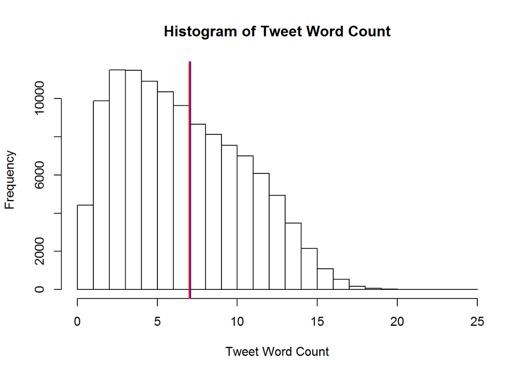

```r
    hist(twitterLength[,1],20,xlab="Tweet Word Count",main="Histogram of Tweet Word Count")
    abline(v = mean(twitterLength[,1]), col = "blue", lwd = 2)
    abline(v = median(twitterLength[,1]), col = "red", lwd = 2)
```

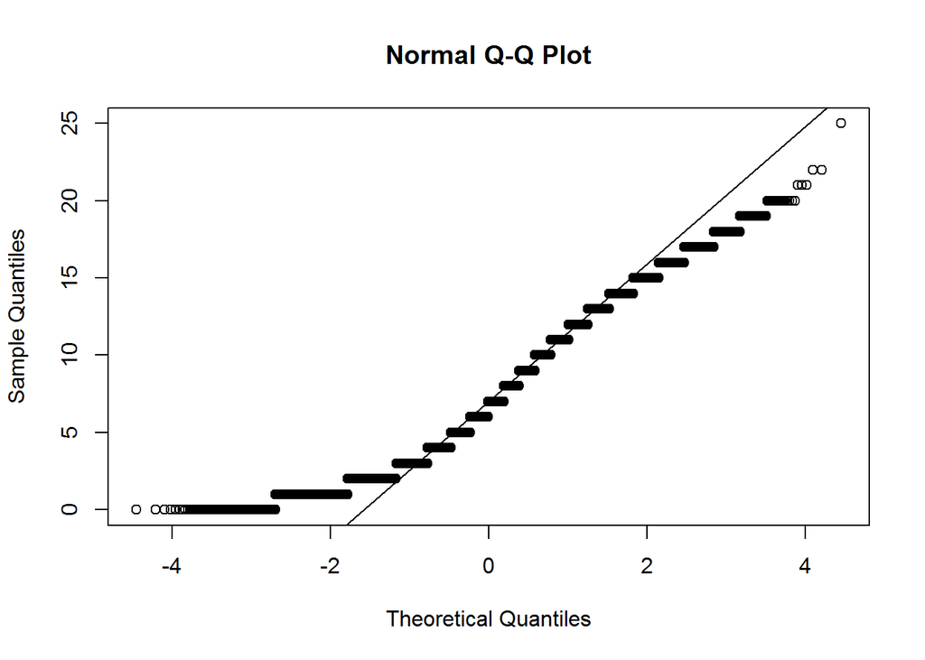

```r
    qqnorm(twitterLength[,1])
    qqline(twitterLength[,1])
```

### News word count

The average word count per tweet is **19.4971517**. The median word count per tweet is **18**. It appears that the news article word count is also skewed to the right. The data has a kurtosis of **7.5658253**. The data is leptokurtic; a lot of variation is explained by extreme values. We reject the hypothesis that the distribution of the word count of news articles is normal.

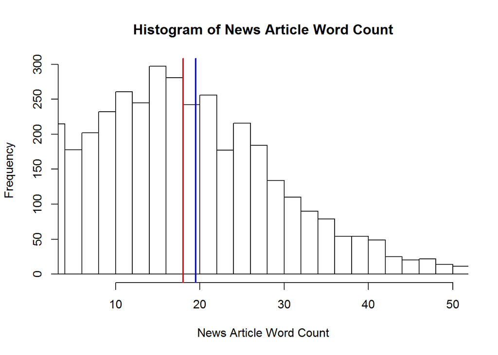

```r
    hist(newsLength[,1],100,xlab="News Article Word Count",main="Histogram of News Article Word Count",xlim=c(5,50))
    abline(v = mean(newsLength[,1]), col = "blue", lwd = 2)
    abline(v = median(newsLength[,1]), col = "red", lwd = 2)
```

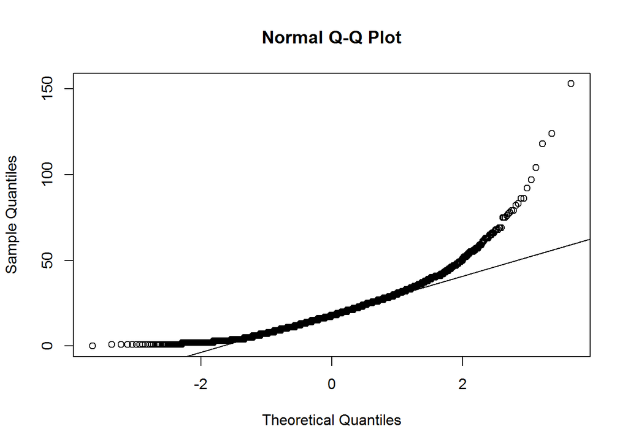

```r
    qqnorm(newsLength[,1])
    qqline(newsLength[,1])
```

### Blog word count

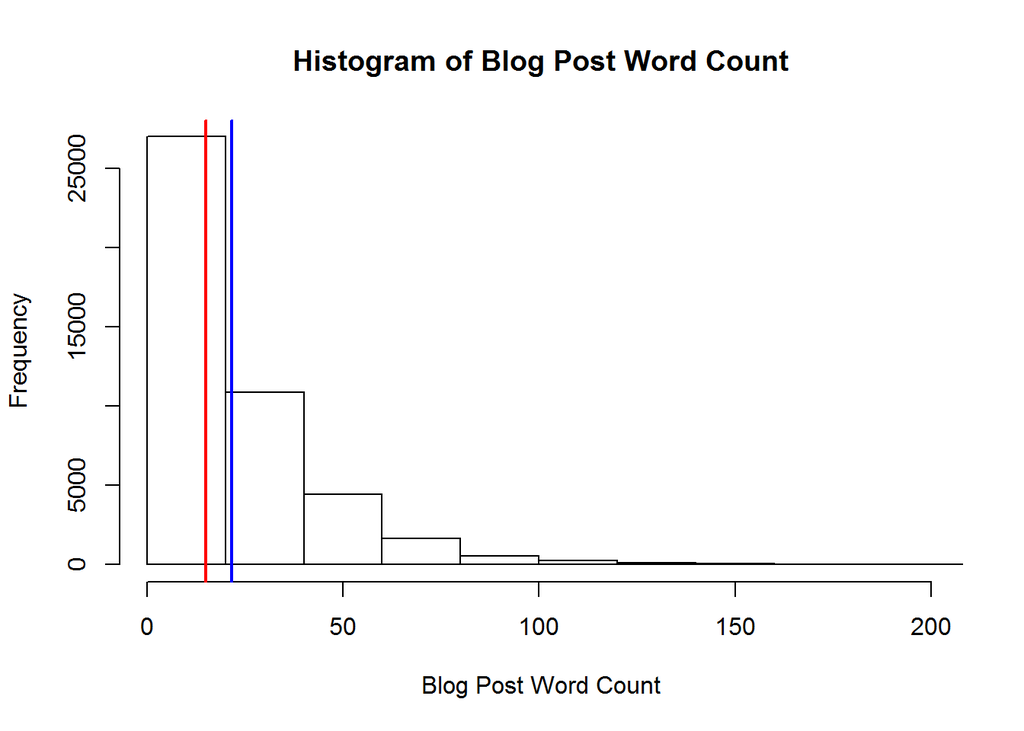

```r
    hist(blogLength[,1],25,xlab="Blog Post Word Count",main="Histogram of Blog Post Word Count",xlim=c(1,200))
    abline(v = mean(blogLength[,1]), col = "blue", lwd = 2)
    abline(v = median(blogLength[,1]), col = "red", lwd = 2)
```

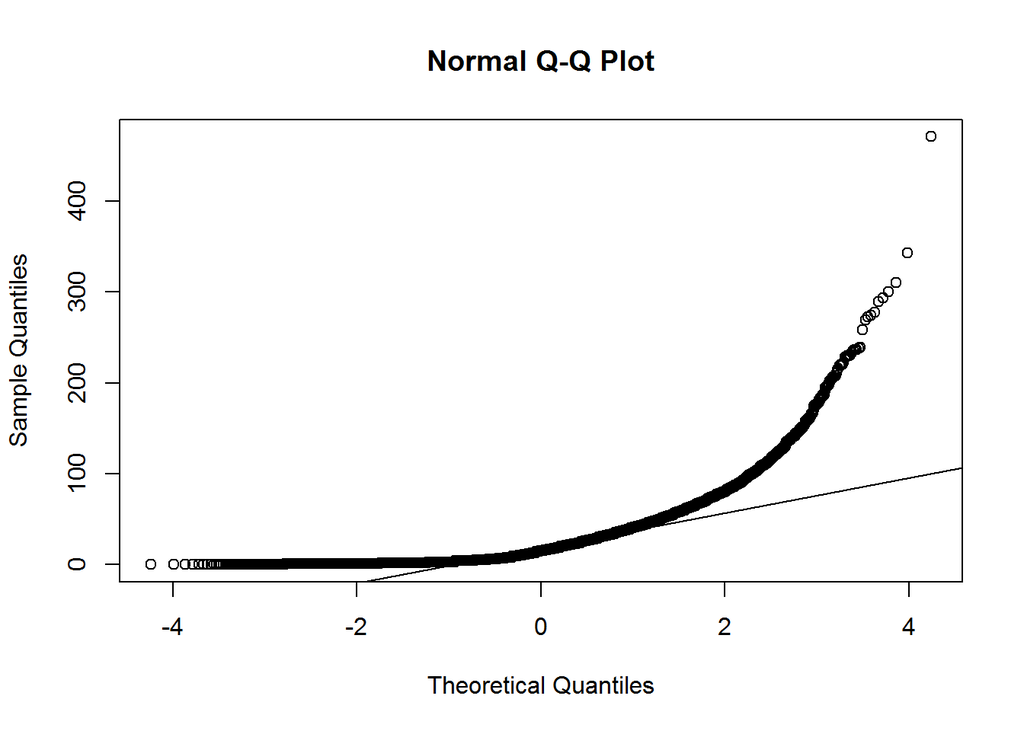

```r
    qqnorm(blogLength[,1])
    qqline(blogLength[,1])
```

# Modelling

If we want to predict the n+1’th word where n is the amount of words the user has typed we need to work with a solution that calculates the probability of the next term. The probability is based on the aggregated twitter, blog and news data. A typical solution for this kind of problems are Markov chains. Where the choice of words are ‘states’ and a user can go from one ‘state’ to the other by typing in the n+1’th word.